# Homework 11

# Submission Instructions

- This homework is not for marks and does not need to be submitted.

# *Two-Way ANOVA Questions*

Recall the memory data from the previous homework:

The datafile **“memory.csv”** contains data from a study looking at the effects of memory on the learning of a foreign vocabulary.

Most of you have probably read that a good strategy for memorizing words in a foreign language is to think of mnemonic keywords. For example, in Tagalog (the official language of the Philippines), the word for eyeglasses is “salamin”. That word sounds much like the English word “salmon,” so a possible strategy would be to imagine a picture of a salmon wearing glasses. This type of encoding strategy has been recommended for years, and people who try it generally report good immediate recall of foreign vocabulary. This fits nicely with dual-coding theories, in which the word is viewed as being stored both lexically and visually. However, the studies that have looked at this phenomenon have generally asked the same participants to recall items at several different times. Since each recall session means an additional practice session, practice and time effects are confounded. To get around this problem, Thomas and Wang (1996) used different participants at the two recall intervals. Data with very nearly the same means and variances as theirs are presented below.

Thomas and Wang (1996) ran a study in which they divided participants into one of three “Strategy” groups, and then tested them at one of two times (5 minutes or 2 days). The strategies were

- **Keyword-Generated**: Participants generated their own keywords to help them to remember 24 Tagalog words.
- **Keyword-Provided:** The experimenters provided the keywords to help them to remember 24 Tagalog words.
- **Rote Learning:** Participants were simply instructed to memorize the meaning of the Tagalog words.

The dependent variable was the number of English words recalled at either 5 minutes or 2 days. Use the **memory.csv** data to answer the questions below.

- Thomas, M. H., & Wang, A. Y. (1996). Learning by the keyword mnemonic: Looking for long-term benefits. *Journal of Experimental Psychology: Applied*, *2*(4), 330–342. https://doi.org/10.1037/1076-898X.2.4.330

```
## Analysis of Variance Table
##
## Response: Recall
##                Df  Sum Sq Mean Sq  F value    Pr(>F)
## Strategy        2  281.26  140.63   7.2244  0.001382 **
## Delay           1 2229.35 2229.35 114.5262 < 2.2e-16 ***
## Strategy:Delay  2  824.54  412.27  21.1791 5.839e-08 ***
## Residuals      72 1401.54   19.47
## ---
## Signif. codes:  0 '***' 0.001 '**' 0.01 '*' 0.05 '.' 0.1 ' ' 1
```

# Question 1

The significant interaction suggests that it would be useful to examine some simple effects. Conduct a simple effects analyses that allows you to evaluate the effect delay has on each type of strategy. i.e., compare delay (5m vs 2d) across each type of strategy.

Display the summary output and list the comparisons you made that are classifed as “simple effects” and state which ones are significant.

e.g., “*Generated 5m vs Generated 2d: significant*”.

```r
# Create a column with all levels
mem$all_levels <- paste(mem$Strategy, mem$Delay, sep = "_")
```

```r
#Create Contrasts
mem$all_levels <- factor(mem$all_levels)

#Determine the order in which R has stored the levels.
levels(mem$all_levels)
```

```
## [1] "Generated_2d" "Generated_5m" "Provided_2d"  "Provided_5m"  "Rote_2d"
## [6] "Rote_5m"
```

```r
cont1 = c(1, 1, 1, 1, -2, -2)
cont2 = c(1, 1, -1, -1, 0, 0)
cont3 = c(-1, 1, 0, 0, 0, 0) # Gen 5m vs Gen 2d
cont4 = c(0, 0, -1, 1, 0, 0) # Prov 5m vs Prov 2d
cont5 = c(0, 0, 0, 0, -1, 1) # Rote 5m vs Rote 2d

grid <- cbind(cont1, cont2, cont3, cont4, cont5)

#Checking if Orthogonal:
# This multiplies each row's cells and then takes the sum of those products.
sum(apply(grid, MARGIN = 1, FUN = prod))
```

```
## [1] 0
```

```r
#Set Contrasts
contrasts(mem$all_levels) <- grid

#Create Model
simp_effs <- lm(Recall ~ all_levels, data = mem)
summary(simp_effs)
```

```
##
## Call:
## lm(formula = Recall ~ all_levels, data = mem)
##
## Residuals:
##     Min      1Q  Median      3Q     Max
## -10.923  -2.000   0.000   2.192  13.231
##
## Coefficients:
##                 Estimate Std. Error t value Pr(>|t|)
## (Intercept)      11.6026     0.4996  23.225  < 2e-16 ***
## all_levelscont1  -1.2372     0.3532  -3.502 0.000796 ***
## all_levelscont2  -0.9038     0.6118  -1.477 0.143964
## all_levelscont3   5.4615     0.8653   6.312    2e-08 ***
## all_levelscont4   9.2692     0.8653  10.713  < 2e-16 ***
## all_levelscont5   1.3077     0.8653   1.511 0.135084
## ---
## Signif. codes:  0 '***' 0.001 '**' 0.01 '*' 0.05 '.' 0.1 ' ' 1
##
## Residual standard error: 4.412 on 72 degrees of freedom
## Multiple R-squared:  0.7041, Adjusted R-squared:  0.6836
## F-statistic: 34.27 on 5 and 72 DF,  p-value: < 2.2e-16
```

# Question 2

How does delay impact the three different strategies, if at all, and what strategy seems best overall.

- Looking at the simple effects, increases in delay significantly decreased recall for all the strategies **except the rote strategy.**
  - Contrary to popular belief, maybe rote learning is not so bad after all?

# Question 3

Instead of doing a simple effects analysis, a bunch of t-tests could have been conducted across the 6 **combinations** of levels. If you took that approach, how many pairwise comparisons would you be making? Find an automated way of determining this in R.

- Hint: the answer you come up with should be $15$. There are functions in base-R that will compute this, but you could also install special packages to do it as well.
- Extra Hint: combinations, not permutations, are what you want
  - https://www.mathsisfun.com/combinatorics/combinations-permutations.html

**Here are 3 simple ways you could potentially solve this:**

```r
# Using ....*shudder* .... Math
factorial(6) / (factorial(2) * factorial(6 - 2))
```

```
## [1] 15
```

```r
# Using the 'choose' function
choose(n = 6, k = 2) # n = number of unique items; #k = size of the combination.
```

```
## [1] 15
```

```r
# Using a library that just lists all the combinations and then counting how many there are.
library(gtools)
nrow(combinations(n = 6, r = 2))
```

```
## [1] 15
```

# Question 4

Given the previous question, if you are making 15 pairwise comparisons, what would your familywise error be if you are using $\alpha = 0.05$? In plain English what does this mean?

```r
1 - (1 - 0.05)^15
```

```
## [1] 0.5367088
```

There is about a 53.671”% chance of making at least one type-I error.

# Question 5

Use a Tukey HSD procedure to compute all 15 pairwise comparisons. Display the output. Do the interpretations differ from your simple effects analyses? Which method (Tukey HSD or simple effects) is preferrable and why?

```r
#Create an ANOVA model
model = aov(Recall ~ all_levels, data = mem)

#Tukey's HSD function
TukeyHSD(model, "all_levels")
```

```
##   Tukey multiple comparisons of means
##     95% family-wise confidence level
##
## Fit: aov(formula = Recall ~ all_levels, data = mem)
##
## $all_levels
##                                  diff         lwr         upr     p adj
## Generated_5m-Generated_2d  10.9230769   5.8563149 15.98983898 0.0000003
## Provided_2d-Generated_2d   -2.0000000  -7.0667621  3.06676206 0.8560061
## Provided_5m-Generated_2d   16.5384615  11.4716995 21.60522360 0.0000000
## Rote_2d-Generated_2d        8.7692308   3.7024687 13.83599283 0.0000433
## Rote_5m-Generated_2d       11.3846154   6.3178533 16.45137745 0.0000001
## Provided_2d-Generated_5m  -12.9230769 -17.9898390 -7.85631486 0.0000000
## Provided_5m-Generated_5m    5.6153846   0.5486226 10.68214668 0.0211991
## Rote_2d-Generated_5m       -2.1538462  -7.2206082  2.91291591 0.8133356
## Rote_5m-Generated_5m        0.4615385  -4.6052236  5.52830052 0.9998093
## Provided_5m-Provided_2d    18.5384615  13.4716995 23.60522360 0.0000000
## Rote_2d-Provided_2d        10.7692308   5.7024687 15.83599283 0.0000004
## Rote_5m-Provided_2d        13.3846154   8.3178533 18.45137745 0.0000000
## Rote_2d-Provided_5m        -7.7692308 -12.8359928 -2.70246871 0.0003710
## Rote_5m-Provided_5m        -5.1538462 -10.2206082 -0.08708409 0.0438827
## Rote_5m-Rote_2d             2.6153846  -2.4513774  7.68214668 0.6582028
```

- Since the *Generated_5m vs Generated_2d* and *Provided_5m-Provided_2d* comparisons are significant and *Rote_5m vs Rote_2d* is not. The interpretations do not differ.
- The simple effects analyses is preferable because Tukey’s HSD is testing a number of unnecessary comparisons which reduce the statistical power.

# Question 6

In the lectures I have said repeatedly that an ANOVA is just multiple linear regression. Consequently, it has all the same assumptions. For the model `Recall ~ Strategy + Delay + Strategy:Delay`, plot the residuals as a function of the fitted values. Does it look like the homogeneity of variance assumption is satisified?

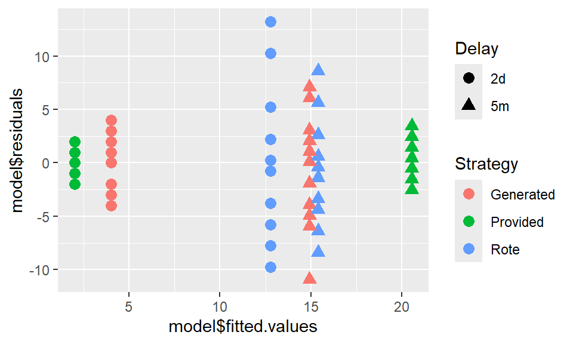

```r
model <- lm(Recall ~ Strategy + Delay + Strategy:Delay,
           data = mem)

ggplot(mem, aes(x = model$fitted.values, y = model$residuals)) +
  geom_point(aes(colour = Strategy, shape = Delay), size = 3)
```

Given the big difference in spread across the fitted values, the assumption of homogeneity does not seem satisfied.

- Note: It is not necessary to separate by colour and shape - it just makes it a bit clearer as to what is happening.

# Question 7

Are the residuals normally distributed? (note: you can sit on the fence if you think it is reasonable to do so - but you need to explain yourself)

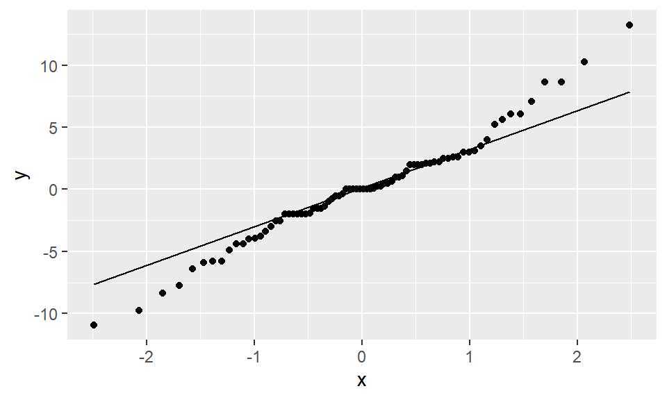

```r
ggplot(mapping = aes(sample = model$residuals)) +
    stat_qq() +
    stat_qq_line()
```

This is a tricky one to say with certainty since the estimated line might be misleading us here. A case could probably be made for either interpretation, but it’s probably wise to assume ‘no’ and look for robust alternatives.

# **Topic: Categorical Variable Analysis**

# Question 8

The following code will store demographic information about the survivors of the Titanic. Columns show how many people survived and didn’t survive. Rows show how many people were male or female.

```r
survive <- as.data.frame(apply(Titanic, c(2, 4), sum))
```

Conduct a test to answer the question “*is survival dependent on sex if you are a passenger on the Titanic?*” Report the test-statistic, degrees of freedom, and p-value. Use of `chisq.test()` is prohibited.

```r
survive <- as.data.frame(apply(Titanic, c(2, 4), sum))
print(survive)
```

```
##          No Yes
## Male   1364 367
## Female  126 344
```

```r
#Marginal Totals
row_tot <- apply(survive, MARGIN = 1, FUN = sum)
col_tot <- apply(survive, MARGIN = 2, FUN = sum)

#Total Sample Size
N <- sum(row_tot)
```

```r
#Expected Values
E11 <- (row_tot[1] * col_tot[1]) / N
E12 <- (row_tot[1] * col_tot[2]) / N
E21 <- (row_tot[2] * col_tot[1]) / N
E22 <- (row_tot[2] * col_tot[2]) / N
```

```r
# Test Statistic
chisq <- (((survive[1, 1] - E11)^2) / E11) +
         (((survive[1, 2] - E12)^2) / E12) +
         (((survive[2, 1] - E21)^2) / E21) +
         (((survive[2, 2] - E22)^2) / E22)

#Degrees of Freedom
df <- (2 - 1) * (2 - 1)

#P-Value
p <- pchisq(chisq, df = df, lower.tail = FALSE)
```

```
## [1] "ChiSq = 456.874, df = 1, p = 0"
```

Since the null hypothesis is rejected we can say that survival on the Titanic is likely to be dependent on sex.

# Question 9

What are the odds of surviving the Titanic if you are a male?

```r
#Survive | male
surv_male <- 367/1364
surv_male
```

```
## [1] 0.2690616
```

The odds are 0.269 times the odds of not surviving.

# Question 10

What are the odds of surviving the Titanic if you are a female?

```r
#Survive | female
surv_female <- 344/126
surv_female
```

```
## [1] 2.730159
```

The odds are 2.73 times the odds of not surviving.

# Question 11

Compute an odds-ratio of survival between males and females. Describe the result in plain English and answer the question, is this a big effect?

```r
#Survive | male : survive | female
odds_rat <- surv_male / surv_female
odds_rat
```

```
## [1] 0.09855163
```

The odds of being a male who survives the sinking of the Titanic is 0.099 times lower than if you are a female.

# Question 12

Plot the survival rates of men and women on the Titanic as a percentage.

```r
# Organize data into tidy format dataframe
Sex <- c("Male", "Male", "Female", "Female")
Survived <- c("No", "Yes", "No", "Yes")

Percentage <- c(
  survive[1, 1] / row_tot[1], survive[1, 2] / row_tot[1],
  survive[2, 1] / row_tot[2], survive[2, 2] / row_tot[2]
) * 100

sunk <- data.frame(Sex, Survived, Percentage)
```

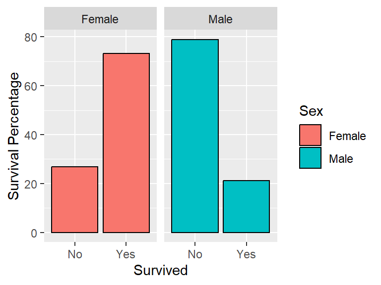

[figure not shown]

```r
library(ggplot2)

ggplot(sunk, aes(x = Survived, y = Percentage)) +
  geom_bar(stat = "identity", aes(fill = Sex), colour = "black") +
  facet_wrap(~ Sex) +
  ylab("Survival Percentage")
```

# Question 13

Did Jack die needlessly or could he have fit on that piece of floating debris with Rose?

[Click Here for the Correct Answer](https://youtu.be/1jXHFEy-ibc?si=0QRNmQfEx2VR3cdW&t=1801)

# Question 14

The following code will store a contingency table describing the frequency of hair and eye colour of a bunch of statistics students.

```r
students <- as.data.frame.matrix(margin.table(HairEyeColor, c(1, 2)))
students <- students[, c(1:2)]
```

Determine if hair colour is likely independent of eye colour. Report the test-statistic, degrees of freedom, and p-value. Use of `chisq.test()` is prohibited.

```r
students <- as.data.frame.matrix(margin.table(HairEyeColor, c(1, 2)))
students <- students[, c(1:2)]
print(students)
```

```
##       Brown Blue
## Black    68   20
## Brown   119   84
## Red      26   17
## Blond     7   94
```

```r
# Get row totals
row_tot <- apply(students, MARGIN = 1, FUN = sum)

# Get Col Totals
col_total <- apply(students, MARGIN = 2, FUN = sum)

# Get Total Number of Observations
N <- sum(col_total)
```

```r
# Calculate Expected Frequencies (using matrix multiplication: %*%)
# t() transposes the data; see note below)
expected <- row_tot %*% t(col_total) / N
```

```r
# Get the Chi-Square Value
chisq <- sum((students - expected)^2 / expected)

# P-Value
df <- (4 - 1) * (2 - 1)
p <- pchisq(chisq, df = df, lower.tail = FALSE)
```

```
## [1] "ChiSq = 108.998, df = 3, p = 0"
```

Hair colour is dependent on eye colour.

- Note: this doesn’t mean hair colour is determined by eye colour, just that there is a dependency between these two variables (i.e., one varies as a function of the other).

**Matrix Multiplication: The best friend you never knew you had.**

- Note also that I used a `%*%` to make my life much easier answering this question. There is no reason you necessarily should have known what that is or how to do it unless you have taken some higher level math.
  - This operator is used to multiply matrices in R, and a vector can just be thought of as a one-dimensional matrix. We can obtain the expected values we need by just multiplying the row and column totals together using matrix multiplication, which is what `%*%` does. The row totals are a $4 \times 1$ matrix and the column totals are a $2 \times 1$ matrix.
  - The function `t()` “transposes” a vector so it represents a set of columns as opposed to rows. Thus transposing the column totals makes it go from a $2 \times 1$ to a $1 \times 2$ matrix.
  - Multiplying the row total matrix with the transposed column total matrix gives you a $4 \times 2$ matrix. This is easiest to understand if you imagine trying to create a multiplication table using two vectors `x` and `y`. Try running this code:

```r
# Code to generate a 5 x 6 multiplication table
x <- 1:5
y <- t(1:6) # note the use of transposition here
x %*% y
```

# Question 15

Use the data from the previous question to recreate the following plot:

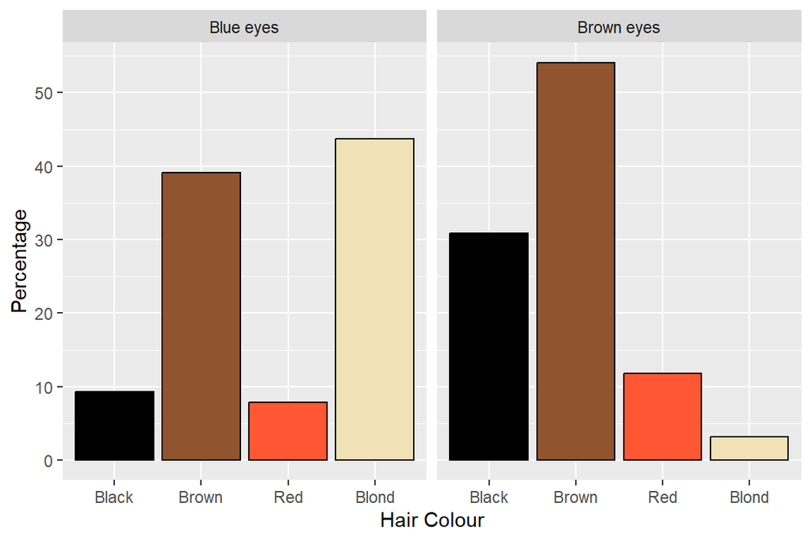

The hex codes used for black, brown, red, and blond respectively are:

`"#000000", "#90542F", "#FF5733", "#F0E2B6"`

```r
#Create Dataframe
colours <- c("Black", "Brown", "Red", "Blond")

hair <- c(rep(colours, 2))

eye <- c(rep("Brown eyes", 4), rep("Blue eyes", 4))

percentage <- c(students$Brown / col_total[1],
                students$Blue / col_total[2]
                ) * 100

plot_data <- data.frame(hair, eye, percentage)
```

```r
# Reorder factor levels so they are in the order we want
plot_data$hair <- factor(plot_data$hair, levels = colours)

palette <- c("#000000", "#90542F", "#FF5733", "#F0E2B6")

# Plot the data
ggplot(plot_data, aes(x = hair, y = percentage)) +
  geom_bar(stat = "identity", aes(fill = hair), colour = "black") +
  facet_wrap(~eye) +
  scale_y_continuous(breaks = seq(0, 100, 10)) +
  scale_fill_manual(values = palette) +
  xlab('Hair Colour') + ylab('Percentage') +
  theme(legend.position = "none")
```

# Question 16

Test the hypothesis that, when you have blue eyes, there is an equal chance of having any of the four hair colours. Report the test-statistic, degrees of freedom, and p-value. Use of `chisq.test()` is prohibited.

```r
#Goodness of fit test on Blue Eyed Students
N = sum(students$Blue)

observed <- students$Blue
expected <- c(1/4, 1/4, 1/4, 1/4) * N

chisq <- sum(((observed - expected)^2) / expected)

df <- 4 - 1

p <- pchisq(chisq, df = df, lower.tail = FALSE)
```

```
## [1] "ChiSq = 93.484, df = 3, p = 0"
```